# Julia Scientific Programming for Beginners

### ──Pythonのように書けて、Cのように速い──

[figure not shown]

# 0.はじめに

PythonやRをはじめとしたプログラミング言語によって分析を行う人が増えてきました。もちろん従来からあるコーディング不要のExcelなども強力な分析ツールではあるのですが、GBクラス以上のデータを扱うには不便だったりするなど、PythonやRを使ったほうが便利な側面もあります。一方、個人的にはその処理能力や速度も「もっと早くなれば良いのにな」と思うところがあり、僕が推したいプログラミング言語はPythonでもなくRでもなく**Julia**です(ちなみにMATLABやOctaveも好きです)。しかしながらPythonやRをはじめとした様々な言語に関しては巷に入門書があふれていますが、開発されて間もない言語だということもありJuliaに関しては少ないため、とりあえず書いてみることにしました。

Juliaは

- Pythonのように書けてCのように早い
- 数値計算、機械学習、統計、データ解析なども得意
- 数式をきれいに書くことができる (例. 2Xを2*Xではなく、2Xと書ける)

といった、ことから最近流行りの言語になっています。実際、非常に高速なのと可読性の高さから、個人的にはPythonやRより優れていると感じています。  
ちなみに、こちらは理化学研究所生命機能科学研究センターの[佐藤建太さんの資料](https://www.slideshare.net/KentaSato/julia-2015?from_action=save) から拝借した図ですが、いかにJuliaが早いかが一目でわかります。

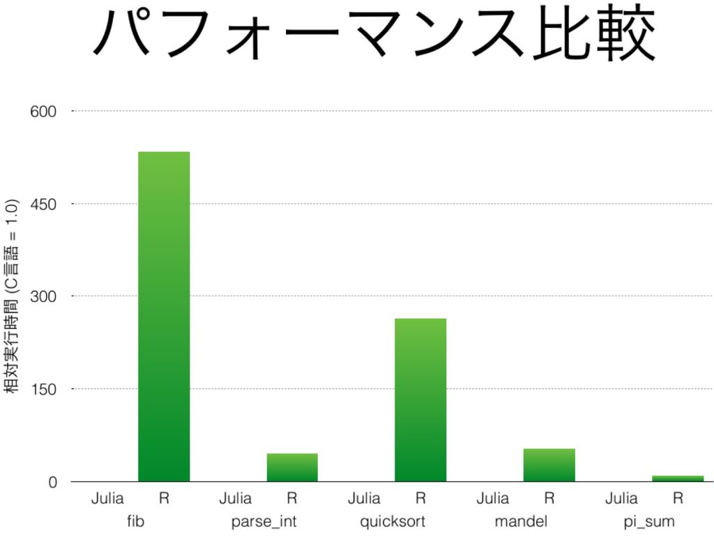

他にも、JuliaのHPを見に行くと

- Cのように早い
- Rubyのような動的さ
- Lispのような真のマクロ
- Rのような統計処理
- Pythonのような汎用性
- Perlの文字処理のように自然
- Shellのような簡単な連結
- MatLabのような線形代数
- シンプルで、学びやすい
- 上級者でも満足できる

と、非常に"貪欲な"言語であることがわかります。(Julia公式も貪欲さがが売りであると公言しています)

> We want a language that's open source, with a liberal license. We want the speed of C with the dynamism of Ruby. We want a language that's homoiconic, with true macros like Lisp, but with obvious, familiar mathematical notation like Matlab. We want something as usable for general programming as Python, as easy for statistics as R, as natural for string processing as Perl, as powerful for linear algebra as Matlab, as good at gluing programs together as the shell. Something that is dirt simple to learn, yet keeps the most serious hackers happy. We want it interactive and we want it compiled.  
> Source: https://julialang.org/blog/2012/02/why-we-created-julia/

なお、「JuliaはPythonの完全上位互換でJuliaさえあればPythonは不要」というわけではなく、Juliaを開発したMITの方々はPythonではできない/苦手な/遅いことをJuliaでやる、という位置づけで使っており、Juliaで仕事をするときにもPythonを呼び出すことはよくあることであることは注意してください。また、JuliaからPythonやRを使うと、直接PythonやRを使った場合よりもさらに一段深い理解が必要になる場合があって、JuliaをやればPythonやRへの理解も深まる場合があるので、PythonやRの勉強も怠らないようにしましょう。  
PythonとJuliaの違いとしては、Pythonは、科学分野の巨大なユーザーコミュニティが既に存在し、優れた科学的・一般的なエコシステムを特徴とする汎用言語です。一方、Juliaは主に技術的・科学的なコンピューティングに特化した言語であり、最先端の手法やアルゴリズムを扱う優れたエコシステムを備えています。どちらも現代的なオープンソースの生産性の高い言語であり，ハイパフォーマンスコンピューティングに必要な様々な機能を備えています。

### 本チュートリアルの想定読者

- Juliaプログラミングに興味がある方
- 新しいプログラミング言語を学びたい方
- Fortran、Pythonなど、既にプログラミング言語を使ったことのある方 (なくても可)

### 本チュートリアルの達成目標

- 自分で簡単なJuliaプログラムをゼロから書けるようになる
- コンピュータ言語としてのJuliaの利点と能力を理解する
- Plots、DataFrames、Statsなどの様々なJuliaパッケージの使用できるようになる

### 本チュートリアルで扱わない・達成できないこと

- 熟練したプログラマーになるためには、**本チュートリアル上の作業だけでは不十分**です。これは、長くて美しく、新しい関係の始まりの"最初のデート"のようなものだとお考え下さい。そして、今回のチュートリアルをきっかけとして、これから先Juliaについて様々な良い点や悪い点について気づき、発見していって下さい。
- 本チュートリアルでは実際のデータを用いた**ケーススタディ的な分析は行いません**。あくまで基本文法や扱い方についての解説のみに終始します。
- 本チュートリアルではプログラミング言語としてのJuliaのみに焦点を当て、**統計学的な内容の解説は行いません**。

### 目次

1. 環境設定
2. 基本的な文法
3. データ構造
4. 配列
5. 制御構造
6. 関数
7. モジュール
8. ファイル入出力
9. 可視化
10. データフレーム
11. 科学計算

# 1.環境構築

以下のURLからJuliaをインストールし、環境構築については下記のqiitaの手順通りに行えば何とかなります。 Juliaをやってみようとする人は既にpythonとかをいじったことがあると思っているのでAnacondaやJupyterは既に入っている前提ですが、入っていない人は適当にググって入れてください。なんならこの記事もJuypter Notebookで書いています。一応参考までに、windowsとmacそれぞれにおけるAnacondaのインストール方法も簡単にですが記述しておきます。

インストール  
https://julialang.org/downloads/

環境構築 (for window)  
https://qiita.com/msekino/items/dbfe11ad05f20fd3efd3

環境構築 (for Mac)  
https://qiita.com/SatoshiTerasaki/items/41df235328badcf382eb

<参考> Anacondaのインストール方法 for Windows

1. Download **Anaconda** (includes Python and Jupyter) from the Anaconda website (https://www.anaconda.com/products/individual#download-section).
2. Save the package to a **C:\Temp** and double-click the file to run the installer.
3. Click **Next**.
4. Read the licensing terms and click **I Agree**.
5. Select install for **Just Me** and click **Next**.
6. Select a destination folder to install Anaconda and click the **Next** button.
7. Choose **Register Anaconda as my default Python 3.7** and click **Install**.
8. After the package has finished installing, click **Next** and then **Finish**.
9. Go to **Start** and open **Anaconda Prompt** and type **python --version** and press **Enter** to check if Python was installed properly. You should see here Python 3.7. If **Python** is **not installed**, you can download it from the Python site (https://www.python.org/downloads/).
10. To open Jupyter Notebook, type **jupyter notebook** in the Anaconda Prompt and press **Enter**.

<参考> Anacondaのインストール方法 for Mac

1. Download Anaconda (includes Python and Jupyter) from the Anaconda website (https://www.anaconda.com/products/individual#download-section).
2. Click the **Anaconda.pkg**
3. On the Installation screen, follow the Installation by clicking on **Continue**.
4. Once the application is installed.
5. Look for **Anaconda Navigator** on the search.

# 2. 基本的な文法

## 2-1. 出力、定数と変数

### 出力

出力をするためにはお馴染みの**printもしくはprintln**をJuliaでも使います  
print("XXXX")  
println("XXXX")  
**lnは改行を表す**ので、何行も出力する場合にはlnを付けたほうがよいですね。

```julia
print("Hello World!")
```

```
Hello World!
```

```julia
println("Hello World!")
```

```
Hello World!
```

### 変数

変数を定義する場合は  
**変数名 = 変数に代入したい値**  
と書くと変数を設定できます。これは整数だけでなく小数なども変数として入力できます。

```julia
#変数xを定義する
x = 10
```

```
10
```

```julia
#変数yを定義する
y = 1.0
```

```
1.0
```

変数の型を確認したい場合は**typeof**を使います

```julia
x = 10
#データ型はInt(整数)となる
typeof(x)
```

```
Int64
```

```julia
y = 1.0
#データ型はfloat(浮動小数点)となる
typeof(y)
```

```
Float64
```

演算も、他の言語と同様にできます

```julia
x = 10
y = 1.0
#x+yを計算する
z = x + y
```

```
11.0
```

```julia
typeof(z)
```

```
Float64
```

普通は式を実行すると結果が表示されますが、毎回結果が返ってくると煩わしい場合には数式の最後に;(セミコロン)を打つと、実行しても結果は表示されなくなります。

```julia
x = 10
y = 1.0
z = x + y;
```

### 定数

x=1  
の後に  
x=10  
とコードを書けば、xの値は1から10に上書きされますが、上書きされたくない定数を定義したい場合は、最初に**const**を付けます

```julia
#定数を定義する
const teisuu = 3.0
```

```
3.0
```

```julia
#定数を上書きしようとする場合にはwarningが出る
teisuu = 10
```

```
invalid redefinition of constant teisuu

Stacktrace:
 [1] top-level scope
   @ In[11]:2
 [2] eval
   @ .\boot.jl:360 [inlined]
 [3] include_string(mapexpr::typeof(REPL.softscope), mod::Module, code::String, filename::String)
   @ Base .\loading.jl:1094
```

## 2-2. 文字列

文字列はダブルクォーテーション("")にて定義します。他の言語とは異なり、**シングルクォーテーション('')では定義できない**ことに注意してください。

```julia
#文字列を定義する
c = "Julia"
```

```
"Julia"
```

```julia
#シングルクォーテーションでは定義できない
cc = 'Julia'
```

```
syntax: character literal contains multiple characters

Stacktrace:
 [1] top-level scope
   @ In[13]:2
 [2] eval
   @ .\boot.jl:360 [inlined]
 [3] include_string(mapexpr::typeof(REPL.softscope), mod::Module, code::String, filename::String)
   @ Base .\loading.jl:1094
```

**文字列の連結は***を用います (他言語とは違い、**+ではない！**)

```julia
h = "Hello "
c = "Julia"
#文字列hとcを連結させる
print(h * c)
```

```
Hello Julia
```

文字の取り出しを行う場合には  
**変数[インデックス]**  
**変数[取り出し開始文字のインデックス:取り出し終了文字のインデックス]**  
と記述します。  
Juliaの場合**インデックスは1から始まる**ので、1文字目を取り出したい場合は0ではなく1を指定してください。

```julia
c = "Julia"
#c、つまり、Juliaの一文字目であるJを取り出す
c[1]
```

```
'J': ASCII/Unicode U+004A (category Lu: Letter, uppercase)
```

```julia
c = "Julia"
#"Julia"の2文字目から4文字目までを取り出す
c[2:4]
```

```
"uli"
```

また、これは後程説明しますが、viewを用いても同様のことが行えます。先述した方法は新しい文字列を作成しているのに対し、viewを用いた場合は元の文字列を参照しているにすぎないのでメモリ消費量を抑えることができます。

```julia
c = "Julia"
#"Julia"の2文字目から4文字目までを取り出す
@view(c[2:4])
```

```
"uli"
```

文字列が何文字で構成されているかを調べるには**length関数**を用います (スペースも1文字として計算されます)

```julia
c = "Julia"
#"Julia"が何文字かを調べる
length(c)
```

```
5
```

```julia
h = "Hello "
c = "Julia"
length(h*c)
```

```
11
```

**split関数**で分割することができます  
**split(分割したい文字列, "何をキーとして分割するか")**  
と記述してください。

```julia
h = "Hello "
c = "Julia"
#半角スペースをキーとして、h * cを分割する
split(h * c," ")
```

```
2-element Vector{SubString{String}}:
 "Hello"
 "Julia"
```

```julia
hh = "Hello,julia"
split(h * c,",")
```

```
1-element Vector{SubString{String}}:
 "Hello Julia"
```

小文字と大文字の変換は、以下のよう記述します。  
lowercase(小文字にしたい文字列)  
uppercase(大文字にしたい文字列)  
これで大文字から小文字、小文字から大文字に変換ができます。

```julia
name = "Julia"
#nameを全て小文字化する
lowercase(name)
```

```
"julia"
```

```julia
name = "Julia"
#nameを全て大文字化する
uppercase(name)
```

```
"JULIA"
```

## 2-3 型変換

### 文字列から数値に変換する

**parse**を用いて  
**parse(変換したい型, 変換したい値)**  
と記述します

```julia
number = "12345"
typeof(number)
```

```
String
```

```julia
number = "12345"
#numberを文字列からInt型に変換する
number1 = parse(Int, number)
```

```
12345
```

```julia
typeof(number1)
```

```
Int64
```

```julia
number = "12345"
#numberを文字列からFloar型に変換する
number2 = parse(Float64, number)
```

```
12345.0
```

```julia
typeof(number2)
```

```
Float64
```

### 数値から文字列への変換する

数値から文字列に変換したい場合は、**string関数**を使用し、  
**string(文字列にしたい値)**  
と記述します。

```julia
number = 12334
typeof(number)
```

```
Int64
```

```julia
str = string(number)
```

```
"12334"
```

```julia
typeof(str)
```

```
String
```

また、**round関数**を用いることで数値を丸めることができ、  
**round(型, 丸めたい数値)**  
と記述します。

```julia
pi = 3.1415
round(pi)
```

```
3.0
```

```julia
round(Int, pi)
```

```
3
```

## 2-4. 演算

### 基本的な演算

基本的な演算はほかの言語と同じです。  
足し算: a + b  
引き算: a - b  
掛け算: a * b  
割り算: a / b  
余り: a % b  
べき乗: a ^ b

```julia
x = 3
y = 5
x+y
```

```
8
```

```julia
x = 3
y = 5
x-y
```

```
-2
```

```julia
x = 3
y = 5
x * y
```

```
15
```

```julia
x = 3
y = 5
x/y
```

```
0.6
```

```julia
x = 3
y = 5
#yをxで割った余りを計算
y % x
```

```
2
```

```julia
x = 3
y = 5
#xのy乗を計算
x ^ y
```

```
243
```

### 論理式

論理式についても、他のプログラミング言語と同様に記述できます。

```julia
x = 3
y = 5
x > y
```

```
false
```

```julia
x = 3
y = 5
x < y
```

```
true
```

```julia
x = 1
y = 0
x != y
```

```
true
```

### 文字についての演算

既にある変数を上書きする際には、ほかのプログラミング言語と同様  
x = x+1  
や  
x += 1  
などといった記述ができます。

```julia
x = 3
#xに1を足したものをxに代入する
x = x+1
```

```
4
```

```julia
x = 3
#xに1を足したものをxに代入する
x += 1
```

```
4
```

```julia
x = 3
#xに1を引いたものをxに代入する
x -= 1
```

```
2
```

1行に複数の作業を行いたい場合には、;(セミコロン)を付けます

```julia
x = 3 ; y = 5
```

```
5
```

```julia
print(x)
```

```
3
```

```julia
print(y)
```

```
5
```

## 2-5. NaN / Inf

### NaN

NaNとはNot-A-Numberの略で非数を表し、Infはinfinitiの略で無限大を表します。 他のプログラミング言語だとNaNの扱いは難しいこともありますが、JuliaだとNaNの扱いも簡単です。  
単純に  
**NaNを代入したい変数 = NaN**  
と入力するだけでNaNを扱えます

```julia
x = NaN
```

```
NaN
```

NaNを判定する場合には**isnan関数**を用います。

```julia
x = NaN
isnan(x)
```

```
true
```

```julia
y = 1
isnan(y)
```

```
false
```

### Inf

Infも  
Infを代入したい変数 = Inf  
と入力することで扱えます。

```julia
z = Inf
```

```
Inf
```

Infか否かを判定するには**isinf関数**を用います。

```julia
z = Inf
isinf(z)
```

```
true
```

```julia
y = 1
isinf(y)
```

```
false
```

# 3. データ構造

## 3-1. タプル

タプルは丸かっこ()で定義をし、カンマ区切りで入力します。

```julia
a = (0,1,2,3,4,5)
```

```
(0, 1, 2, 3, 4, 5)
```

```julia
#型はtupleとなる
typeof(a)
```

```
NTuple{6, Int64}
```

実は丸かっこ()なしでもタプルを定義することができます。

```julia
b = 2,3,4,5
```

```
(2, 3, 4, 5)
```

```julia
typeof(b)
```

```
NTuple{4, Int64}
```

タプルの中の要素の取り出しは他のプログラミング言語と同様にインデックスを指定して行いますが、**Juliaの場合はインデックスが1から始まる**ことに気を付けてください。  
また、タプルはスライスも他の言語と同様に実行することができます。

```julia
a = (0,1,2,3,4,5)
#タプルaの一番最初の要素を取り出す。
a[1]
```

```
0
```

```julia
a = (0,1,2,3,4,5)
#タプルの1番目から3番目までの要素を取り出す。
a[1:3]
```

```
(0, 1, 2)
```

**(重要) タプルはimmutableなので、一度作成したらその中の値を変更することはできません。**

```julia
a = (0,1,2,3,4,5)
#タプルaの1番目の要素を10に変更しようとするとエラーが返ってくる
a[1] = 10
```

```
MethodError: no method matching setindex!(::NTuple{6, Int64}, ::Int64, ::Int64)

Stacktrace:
 [1] top-level scope
   @ In[61]:3
 [2] eval
   @ .\boot.jl:360 [inlined]
 [3] include_string(mapexpr::typeof(REPL.softscope), mod::Module, code::String, filename::String)
   @ Base .\loading.jl:1094
```

タプルにはタプル内の各要素に名前を付けることもできます。  
また、要素を取り出す際には以下のように名前を指定して取り出すこともできます。  
**タプル名.要素名**

```julia
t = (x = 1, y = 2, z = 3)
```

```
(x = 1, y = 2, z = 3)
```

```julia
#名前が付けられたタプルの型はNamedTupleとなる。
typeof(t)
```

```
NamedTuple{(:x, :y, :z), Tuple{Int64, Int64, Int64}}
```

```julia
t = (x = 1, y = 2, z = 3)
#タプルt内の、xの要素を取得
t.x
```

```
1
```

タプル内容その名前(キー)のみを取り出したい場合には**keys関数**を用います。  
また、値のみを取り出したい場合には**values関数**を用います

```julia
t = (x = 1, y = 2, z = 3)
keys(t)
```

```
(:x, :y, :z)
```

```julia
t = (x = 1, y = 2, z = 3)
values(t)
```

```
(1, 2, 3)
```

タプルの要素数を参照する場合には**length**関数を用います。

```julia
t = (x = 1, y = 2, z = 3)
length(t)
```

```
3
```

タプルにすべて要素が入っているのかを確かめる場合には**isempty関数**を用います。

```julia
t = (x = 1, y = 2, z = 3)
isempty(t)
```

```
false
```

## 3-2. リスト

リストはタプルと似たような形をしていますが、タプルとは違って一度定義した中身を変更することができます。  
リストはブラケット[]を用いて定義します。

```julia
l = [1, 2, 3]
```

```
3-element Vector{Int64}:
 1
 2
 3
```

また、ブラケットの中身に何も入れなかった場合は空の1次元配列が生成されます。

```julia
l = []
```

```
Any[]
```

この場合、"空のリスト"ではなく、Any型成分のVectorとなります。これを空のリストが作成されると考えてしまうと、意図しないところでベクトルが生成されることになってしまい、予想以上に計算が遅くなってしまう可能性があります。  
例えば、  
**sum([f(x) for x in X])**  
と記述すると、ブラケットで囲んでいるために意図せずにベクトルが生成されてしまいますが、同様の演算であれば、  
**sum(f(x) for x in X)**  
と記述すればベクトルが作られずに済みます。  
また、  
**sum(f, X)** と書くのが最もシンプルです。

```julia
typeof(l)
```

```
Vector{Any} (alias for Array{Any, 1})
```

タプルと同様、要素が入っているか否かを確かめるには**isempty関数**を用います

```julia
l = []
isempty(l)
```

```
true
```

要素の追加には**push**を用い、  
**push!(追加したいリスト, 追加したい要素)**  
と記述すると、**要素を末尾に追加**することができます。

```julia
l = []
push!(l, 1)
```

```
1-element Vector{Any}:
 1
```

```julia
push!(l, 10)
```

```
2-element Vector{Any}:
  1
 10
```

要素をリストの先頭に加えたい場合は**pushfirst**を用い、  
**pushfirst!(追加したいリスト, 追加したい要素)**  
と記述します。

```julia
pushfirst!(l, 20)
```

```
3-element Vector{Any}:
 20
  1
 10
```

### リストの結合

リストの結合には**append関数**を用い  
**append!(元のリスト, 元のリスト追加したいリスト)**  
と記述することで行うことができます。

```julia
s = [30, 40, 50]
append!(l, s)
```

```
6-element Vector{Any}:
 20
  1
 10
 30
 40
 50
```

リストの追加を行った際、追加元のリストには元のリストに新しく積要素が追加されたリストとなりますが、追加したリストの要素は変化しません。

```julia
l
```

```
6-element Vector{Any}:
 20
  1
 10
 30
 40
 50
```

```julia
s
```

```
3-element Vector{Int64}:
 30
 40
 50
```

### リストの末尾の参照

```julia
pop!(l)
#リストlの末尾の要素のみを取得
```

```
50
```

### 好きな場所に要素を追加

リストの先頭でも末尾でもなく、任意の場所に要素を追加したい場合は**insert関数**を用いて  
**insert!(リスト名, 追加したい場所, 追加したい要素)**  
と記述します。

```julia
insert!(l ,3, 1000)
#リストlの3番目に1,0000を追加
```

```
6-element Vector{Any}:
   20
    1
 1000
   10
   30
   40
```

### 要素の削除

要素をリストから削除する場合は**deleteat関数**を用いて  
**deleteat!(リスト名, 削除したい要素の場所)**  
と記述します。

```julia
deleteat!(l, 3)
#要素番号が3の1,000をリストlから削除
```

```
5-element Vector{Any}:
 20
  1
 10
 30
 40
```

### スライス / ビュー

タプルと同様に、リストでもスライスを行うことができます。

```julia
l[2:4]
#リストlの2番目から4番目までの要素を取得
```

```
3-element Vector{Any}:
  1
 10
 30
```

後述しますが、スライスとほぼ同様の操作をviewを用いることでも行うことができます。スライスでは、スライスした後のリストは元リストとは別なリストとなってしまうので新たなメモリ割り当てが必要となります。一方、viewは元リストを参照しているものにすぎないので、**スライスよりもviewを使った方がメモリ消費を抑えられます**。

```julia
a = collect(1:5)
c = @view(a[2:4])
```

```
3-element view(::Vector{Int64}, 2:4) with eltype Int64:
 2
 3
 4
```

### リストの最大・最小

最大値の取得には**maximum関数**、最小値の取得には**minimum関数**を用い、  
maximum(リスト名)  
minimum(リスト名)  
と記述します。

```julia
maximum(l)
```

```
40
```

```julia
minimum(l)
```

```
1
```

## 3-3. 辞書型

辞書（dictionary）型とは、keyとvalueの組み合わせが含まれているデータのことです。  
辞書型の定義は、dictを用いて、  
**Dict("keyの名前" => keyに対応するvalue)**  
と入力します。  
また、辞書型のデータセットは順序を持たず、リストと同様定義後に内容の上書きが可能です。

```julia
#辞書dを定義する。
d = Dict("A" => 1, "B" => 2, "C" => 3)
```

```
Dict{String, Int64} with 3 entries:
  "B" => 2
  "A" => 1
  "C" => 3
```

```julia
typeof(d)
```

```
Dict{String, Int64}
```

辞書型のvalueは数値だけでなく、文字列でも可能です。

```julia
d = Dict("A" => "Apple", "B" => "Banana", "C" => "Cherry")
```

```
Dict{String, String} with 3 entries:
  "B" => "Banana"
  "A" => "Apple"
  "C" => "Cherry"
```

### keyからvalueの取得 (その1)

辞書内のvalueを取得する場合は  
**辞書名["key名"]**  
と記述することで、対応するkeyのvalueを取得できます。

```julia
d = Dict("A" => "Apple", "B" => "Banana", "C" => "Cherry")
#辞書d内のkeyが"A"のvalueを取得
d["A"]
```

```
"Apple"
```

### 辞書の要素の追加

辞書に新しい要素を追加する場合は  
**辞書名["新しいkey"] = "新しいvalue"**  
と記述します。

```julia
d = Dict("A" => "Apple", "B" => "Banana", "C" => "Cherry")
#辞書dに新たなkey"D"を追加
d["D"] = "Durian"
d
```

```
Dict{String, String} with 4 entries:
  "B" => "Banana"
  "A" => "Apple"
  "C" => "Cherry"
  "D" => "Durian"
```

### 辞書から要素の削除

要素の削除には**pop**もしくは**delete**を使用し、  
**pop!(辞書名, "削除したいkey名")**もしくは  
**delete!(辞書名, "削除したいkey名")**  
と記述することで該当のkeyとvalueを辞書から消すことができます。

```julia
#辞書から"C"を削除する
pop!(d, "C")
```

```
"Cherry"
```

```julia
d
```

```
Dict{String, String} with 3 entries:
  "B" => "Banana"
  "A" => "Apple"
  "D" => "Durian"
```

```julia
#辞書から"A"を削除する
delete!(d, "A")
```

```
Dict{String, String} with 2 entries:
  "B" => "Banana"
  "D" => "Durian"
```

### keyの有無を確認

辞書内にあるkeyがあるか否かを確認する際には、**haskey**を用いて、  
**haskey(辞書名, "存在を確認したいkey名")**  
と記述します。

```julia
d = Dict("A" => "Apple", "B" => "Banana", "C" => "Cherry")
#dの中に"B"というkeyが存在するか否かを確認
haskey(d, "B")
```

```
true
```

```julia
d = Dict("A" => "Apple", "B" => "Banana", "C" => "Cherry")
#dの中に"E"というkeyが存在するか否かを確認
haskey(d, "E")
```

```
false
```

### keyからvalueを取得(その2)

辞書内のkeyに対応するvalueを取得する場合は**get関数**を用いて  
**get(辞書名, "valueを取得したいkey名", "keyが存在しなかったときに返す値")**  
と記述します。

```julia
d = Dict("A" => "Apple", "B" => "Banana", "C" => "Cherry")
#d内に"A"が存在すれば、そのvalueを返し、なければ"NA"を返す
get(d, "A", "NA")
```

```
"Apple"
```

```julia
d = Dict("A" => "Apple", "B" => "Banana", "C" => "Cherry")
#d内に"E"が存在すれば、そのvalueを返し、なければ"NA"を返す
get(d, "E", "NA")
```

```
"NA"
```

### 辞書の統合

複数の辞書を1つに統合したい場合は**merge**を使用して、  
**merge(統合したい辞書1の名前, 統合したい辞書2の名前)**  
と記述します。

```julia
fruit = Dict(11 => "Apple", 12 => "Banana", 13=> "Cherry")
vegitable = Dict(20 => "Avocado", 21 => "Broccoli", 22 => "Carrot")
#辞書fruitoと辞書vegitableを統合
fresh_food = merge(fruit, vegitable)
```

```
Dict{Int64, String} with 6 entries:
  22 => "Carrot"
  13 => "Cherry"
  20 => "Avocado"
  11 => "Apple"
  21 => "Broccoli"
  12 => "Banana"
```

# 4. 配列

## 4-1. 配列の定義

### 一次元配列の定義

配列はブラケット[]を用いて定義します。  
**一次元配列は列ベクトル**となることに注意してください。

```julia
#要素が1つの配列を作成する
[1]
```

```
1-element Vector{Int64}:
 1
```

```julia
#複数の要素を持った配列を定義する
[1, 2, 3]
```

```
3-element Vector{Int64}:
 1
 2
 3
```

### 型を指定して配列を定義する

型を指定して配列を定義する場合は、配列の前に以下のように、型名を記述します  
**型名[配列]**

```julia
#floatでの配列を作成する
Float64[4, 5, 6]
```

```
3-element Vector{Float64}:
 4.0
 5.0
 6.0
```

### 二次元配列の定義

一次元配列と同様にブラケットを使用[]しますが、要素間はカンマではなく**スペースで区切る**ことに注意してください。(カンマを使用するとエラーを起こします。)  
**[要素 要素: 要素 要素]**

```julia
#二次元配列を定義する
[1 2; 3 4]
```

```
2×2 Matrix{Int64}:
 1  2
 3  4
```

```julia
#スペースではなくカンマで区切ると構文エラーが発生する
[1,2 ; 3,4]
```

```
syntax: unexpected semicolon in array expression around In[103]:2

Stacktrace:
 [1] top-level scope
   @ In[103]:2
 [2] eval
   @ .\boot.jl:360 [inlined]
 [3] include_string(mapexpr::typeof(REPL.softscope), mod::Module, code::String, filename::String)
   @ Base .\loading.jl:1094
```

セミコロンの代わりに改行でも二次元配列を記述することができます。

```julia
#二次元配列を定義する
[1 2
    3 4]
```

```
2×2 Matrix{Int64}:
 1  2
 3  4
```

### 配列の要素の取得

配列から要素を取得する場合には  
**配列の名前[取り出したい配列の行数, 取り出したい配列の列数]**  
と記述します。この際、行数・列数は0からではなく**1から始まる**ことに注意してください。

```julia
A = [1 2 3;
    4 5 6;
    7 8 9]
#配列Aの2行1列目の要素を取得する
A[2,1]
```

```
4
```

## 4-2. 配列の初期化

### 初期化されていない配列

まず、初期化された配列を作成する前に、初期化がなされていない配列を作ってみます。初期化されていない配列は**Array**を用いて  
**Array{配列の型}(undef, 配列の行数, 配列の列数)**  
と記述して作成します。

```julia
#値が初期化されていない3×4の大きさの配列を用意する
#型は中括弧{}で指定する。今回は単精度(Float32)
Array{Float32}(undef, 3, 4)
```

```
3×4 Matrix{Float32}:
 1.95933f-22  0.0          1.8214f-29   0.0
 0.0          1.95935f-22  0.0          1.81014f-29
 1.95933f-22  0.0          1.79036f-29  0.0
```

### 0 or 1で初期化された配列

0で初期化された配列を作成するには**zeros**を用いて  
**zeros(配列の要素の型, 配列の行数, 配列の列数)**  
と記述します。  
同様に、1で初期化された配列を作成する場合は、zerosの代わりに**ones**を用い、  
**ones(配列の要素の型, 配列の行数, 配列の列数)**  
と記述します。

```julia
#0で初期化された2行3列の配列を作成する
zeros(Float32, 2, 3)
```

```
2×3 Matrix{Float32}:
 0.0  0.0  0.0
 0.0  0.0  0.0
```

```julia
#1で初期化された2行3列の配列を作成する
ones(Float32, 2, 3)
```

```
2×3 Matrix{Float32}:
 1.0  1.0  1.0
 1.0  1.0  1.0
```

### 正規分布に従う乱数で初期化された配列

乱数で配列を初期化する場合は、**randn**を用いて、  
**randn(配列の型, 配列の行数, 配列の列数)**  
と記述します。

```julia
#3×3の正規分布に従う配列を作成
randn(Float32, 3, 3)
```

```
3×3 Matrix{Float32}:
 -1.66362   -0.48042    0.524301
 -0.403346  -1.12809   -2.10116
  1.29738   -0.164334   0.184538
```

### 自分の好きな値で初期化された配列

好きな値で配列を初期化したい場合は、**fill**を用いて、  
**fill(好きな値, 配列の行数, 配列の列数)**  
と記述します。

```julia
#要素が100で3×3の配列を初期化
fill(100, 3, 3)
```

```
3×3 Matrix{Int64}:
 100  100  100
 100  100  100
 100  100  100
```

### 配列のサイズ変更

配列のサイズを変える場合には**reshape関数**を用いて、  
**reshape（サイズを変えたい配列名, 新しい行数, 新しい列数）**  
と記述します。 この際、**列を優先**して配列のサイズが変更されます。

```julia
#3×4の配列を作成
A = [1 2 3 4;
    5 6 7 8;
    9 10 11 12]
```

```
3×4 Matrix{Int64}:
 1   2   3   4
 5   6   7   8
 9  10  11  12
```

```julia
#配列Aを4×3に変更する
#配列の要素は列を優先されるので、左上から順に1,5,9,2,6,10,…と埋まっていく
reshape(A, 4, 3)
```

```
4×3 Matrix{Int64}:
 1   6  11
 5  10   4
 9   3   8
 2   7  12
```

## 4-3. CopyとDeepcopy

配列を代入する際に、参照渡しで代入すると、**代入先を書き換えると代入元も同時に書き換わってしまいます**。

```julia
#正規分布に従う3×3の配列を作成
A = randn(3, 3)
#配列AをBに参照渡しで代入する(この時点で配列AとBの中身は同一になる)
B = A
```

```
3×3 Matrix{Float64}:
 -0.982439  0.435131  -2.19866
  0.963012  0.320554  -1.23279
  0.659732  0.230722  -1.20893
```

```julia
#配列Bの1行1列の要素を1に変更
B[1, 1] = 1
```

```
1
```

```julia
B
```

```
3×3 Matrix{Float64}:
 1.0       0.435131  -2.19866
 0.963012  0.320554  -1.23279
 0.659732  0.230722  -1.20893
```

```julia
#配列Bの1行1列を1に変更しただけだが、配列Aの1行1列の要素も1になる
A
```

```
3×3 Matrix{Float64}:
 1.0       0.435131  -2.19866
 0.963012  0.320554  -1.23279
 0.659732  0.230722  -1.20893
```

### copy

参照先の内容を変更しても参照元の内容を変更させないためには、**コピー**によって代入を行う必要があります。コピーは**copy**を用いて、  
**copy(参照元の配列名)**  
と記述します。

```julia
#正規分布に従う3×3の配列を作成
A = randn(3, 3)
#配列AをBに参照渡しで代入する(この時点で配列AとBの中身は同一になる)
B = copy(A)
```

```
3×3 Matrix{Float64}:
  2.35068    -0.017878   1.77365
  0.486994    0.137476  -0.0893115
 -0.0643723   0.566355  -1.14023
```

```julia
#Bの1行1列目に1を代入
B[1, 1] = 1
B
```

```
3×3 Matrix{Float64}:
  1.0        -0.017878   1.77365
  0.486994    0.137476  -0.0893115
 -0.0643723   0.566355  -1.14023
```

```julia
#copyを行うと、参照元である配列Aの値は変わらない
A
```

```
3×3 Matrix{Float64}:
  2.35068    -0.017878   1.77365
  0.486994    0.137476  -0.0893115
 -0.0643723   0.566355  -1.14023
```

### deepcopy

配列の中に配列が入っているような再帰的なパターンをコピーしたい場合には**deepcopy**を用いて、  
**deepcopy(参照元の配列名)**  
と記述します。  
**単純なコピーでは配列の中の配列まではコピーしきれない**ことに注意してください。

```julia
#1行1列の配列を作成
hoge = [1]
#配列の中身に配列を入れる
A = [hoge, hoge, hoge]
```

```
3-element Vector{Vector{Int64}}:
 [1]
 [1]
 [1]
```

```julia
#Aをコピーする
B = copy(A)
#配列Bの1つ目の要素の1つ目の要素を2に変換する
B[1][1] = 2
B
```

```
3-element Vector{Vector{Int64}}:
 [2]
 [2]
 [2]
```

```julia
#ただコピーをしただけだと元のhogeが2になってしまう。
hoge
```

```
1-element Vector{Int64}:
 2
```

```julia
#hogeが2になってしまったので、配列Aも全て2になってします。
A
```

```
3-element Vector{Vector{Int64}}:
 [2]
 [2]
 [2]
```

```julia
#1行1列の配列を作成し、配列の中身に配列を入れる
hoge = [3]
A = [hoge, hoge, hoge]
```

```
3-element Vector{Vector{Int64}}:
 [3]
 [3]
 [3]
```

```julia
#deepcopyを使用
B = deepcopy(A)
#配列Bの1つ目の要素の1つ目の要素を0に変換する
B[1][1] = 0
B
```

```
3-element Vector{Vector{Int64}}:
 [0]
 [0]
 [0]
```

```julia
#deepcopyを行った場合は、hogeの値は変更しない
hoge
```

```
1-element Vector{Int64}:
 3
```

```julia
#同様に、配列Aの中身も変更しない
A
```

```
3-element Vector{Vector{Int64}}:
 [3]
 [3]
 [3]
```

## 4-4. 配列の演算

### 配列のサイズがそろっている場合の演算

演算する際には基本的には配列のサイズが同じである必要があります。  
また、足し算や引き算はそれぞれの要素ごとに計算しますが、掛け算は配列を行列とみなしての計算となることに注意してください。

```julia
#すべて1の要素を持つ3×3の配列を定義する
A = ones(Float32, 3, 3)
#すべて2の要素を持つ3×3の配列を定義する
B = fill(2.0, 3, 3)
#A+Bを計算
A+B
```

```
3×3 Matrix{Float64}:
 3.0  3.0  3.0
 3.0  3.0  3.0
 3.0  3.0  3.0
```

```julia
A = ones(Float32, 3, 3)
B = fill(2.0, 3, 3)
#A-Bを計算
A-B
```

```
3×3 Matrix{Float64}:
 -1.0  -1.0  -1.0
 -1.0  -1.0  -1.0
 -1.0  -1.0  -1.0
```

```julia
A = ones(Float32, 3, 3)
B = fill(2.0, 3, 3)
#A*Bを計算(席は行列としての演算になる)
A*B
```

```
3×3 Matrix{Float64}:
 6.0  6.0  6.0
 6.0  6.0  6.0
 6.0  6.0  6.0
```

配列の各要素をスカラー倍したい場合は、  
**スカラー倍したい数値の入った変数名 * 配列名**  
と記述します。

```julia
c = 10
A = ones(Float32, 3, 3)
c * A
```

```
3×3 Matrix{Float32}:
 10.0  10.0  10.0
 10.0  10.0  10.0
 10.0  10.0  10.0
```

### 配列のサイズがそろっていない場合の演算

一般的には配列のサイズがそろっていない配列同士の演算はできませんが、**.+**など、計算記号の前に**.を付けて(ドット演算子)**を用いることで、足す配列のサイズを拡張して無理やり計算を行うことができます。

```julia
#各要素が1の3×3の配列を定義する
A = ones(Float32, 3, 3)
#値が2の3次元ベクトルを定義する
B = fill(2,3)
#配列のサイズが違うので足し算をしてもエラーが出る
A + B
```

```
DimensionMismatch("dimensions must match: a has dims (Base.OneTo(3), Base.OneTo(3)), must have singleton at dim 2")

Stacktrace:
 [1] promote_shape
   @ .\indices.jl:183 [inlined]
 [2] promote_shape(a::Matrix{Float32}, b::Vector{Int64})
   @ Base .\indices.jl:169
 [3] +(A::Matrix{Float32}, Bs::Vector{Int64})
   @ Base .\arraymath.jl:45
 [4] top-level scope
   @ In[132]:6
 [5] eval
   @ .\boot.jl:360 [inlined]
 [6] include_string(mapexpr::typeof(REPL.softscope), mod::Module, code::String, filename::String)
   @ Base .\loading.jl:1094
```

```julia
#無理やり演算を実行する場合には".+"を用いる(Bを3×3拡張する)
A .+ B
```

```
3×3 Matrix{Float32}:
 3.0  3.0  3.0
 3.0  3.0  3.0
 3.0  3.0  3.0
```

```julia
A = ones(Float32, 3, 3)
B = fill(2,3)
#Bを3×3拡張して引き算
A .- B
```

```
3×3 Matrix{Float32}:
 -1.0  -1.0  -1.0
 -1.0  -1.0  -1.0
 -1.0  -1.0  -1.0
```

```julia
A = ones(Float32, 3, 3)
c = 10
#ドット演算子はスカラーにも適用できる
A .+ c
```

```
3×3 Matrix{Float32}:
 11.0  11.0  11.0
 11.0  11.0  11.0
 11.0  11.0  11.0
```

```julia
A = ones(Float32, 3, 3)
c = 10
A ./ c
```

```
3×3 Matrix{Float32}:
 0.1  0.1  0.1
 0.1  0.1  0.1
 0.1  0.1  0.1
```

## 4-5. 配列に使う関数

### map関数 (配列内の要素の操作)

**map関数**を用いて、配列内の要素を一気に操作することができます。  
**map(x -> 操作名, 適用したい配列名)**  
と記述します。

```julia
#配列Aを一様分布に従う値で初期化
A = rand(3, 3)
```

```
3×3 Matrix{Float64}:
 0.0728186  0.0995061  0.546526
 0.642058   0.541331   0.582146
 0.288472   0.383256   0.380426
```

```julia
#map関数で配列Aの値をすべて10倍する（ドット演算子を使ってスカラー倍することでも同様の操作が可能）
map(x -> x*10, A)
```

```
3×3 Matrix{Float64}:
 0.728186  0.995061  5.46526
 6.42058   5.41331   5.82146
 2.88472   3.83256   3.80426
```

### push関数 / pop関数 (配列への要素の追加/削除)

配列の末尾に要素を追加する際には以前紹介した**push**を配列に関しても使用することができます。  
**push!(配列名, 末尾に追加したい要素名)**  
と記述します。  
一方で、配列の末尾を削除する場合には**pop**を用います。

```julia
A = Vector(1:5)
#Aの末尾に0を追加
push!(A, 0)
```

```
6-element Vector{Int64}:
 1
 2
 3
 4
 5
 0
```

```julia
#配列の末尾を削除
pop!(A)
A
```

```
5-element Vector{Int64}:
 1
 2
 3
 4
 5
```

### reduce関数 (配列内の要素の和/積を計算する)

配列内の全ての要素の和/積を計算したい場合は**reduce関数**を用いて、  
**reduce(+, 和をとりたい配列名)**  
**reduce(*, 積をとりたい配列名)**  
と記述します。

```julia
A = Vector(1:5)
#配列Aのすべての要素の和を求める
reduce(+, A)
```

```
15
```

```julia
A = Vector(1:5)
#配列Aのすべての要素の積を求める
reduce(*, A)
```

```
120
```

### filter関数 (ある特定の条件を満たす要素を抜き出す)

配列から特定の条件を満たす要素を抜き出す場合には、**filter関数**を使って、配列を対象に評価式を作って値を抜き出します。  
**filter(評価式, 配列名)**  
と記述します。

```julia
A = Vector(1:10)
#配列Aから奇数のみを取り出す
filter(isodd, A)
```

```
5-element Vector{Int64}:
 1
 3
 5
 7
 9
```

```julia
A = Vector(1:10)
#配列Aから偶数のみを取り出す
filter(iseven, A)
```

```
5-element Vector{Int64}:
  2
  4
  6
  8
 10
```

### size関数 / length関数 (配列の形状・要素数の取得)

配列の形状を取得する場合には、**size関数**、要素数を取得する場合には**length関数**を使用します。

```julia
A = Vector(1:10)
#配列の形状を取得
size(A)
```

```
(10,)
```

```julia
A = Vector(1:10)
#配列の要素数を取得
length(A)
```

```
10
```

### sort関数 (要素の並べ替え)

配列内の要素を並び替えたいときには**sort関数**を用いて、  
**sort(要素を昇順に並び替えたい配列名)**  
**sort(要素を降順に並び替えたい配列名, rev=true)**  
と記述します。

```julia
A = Vector(5:-1:1)
```

```
5-element Vector{Int64}:
 5
 4
 3
 2
 1
```

```julia
#配列を昇順に並び替える
sort(A)
```

```
5-element Vector{Int64}:
 1
 2
 3
 4
 5
```

```julia
#配列を降順に並び替える
sort(A, rev=true)
```

```
5-element Vector{Int64}:
 5
 4
 3
 2
 1
```

# 5. 制御構造

## 5-1. if文

他の言語と同様、Juliaにもif文が存在します。ただし、if文の最後に**end**が必要になることに注意してください。  
また、下記の例ではインデントを付けて記述していますが、juliaの場合は**インデントを付けなくてもif文は動作**します。

```julia
name = "apple"
#nameがappleの際にはapple、それ以外の場合はelseを返すif文
if name == "apple"
    println("apple")
else
    println("else")
end
```

```
apple
```

```julia
name = "banana"
#nameがappleの際にはapple、それ以外の場合はelseを返すif文
if name == "apple"
    println("apple")
else
    println("else")
end
```

```
else
```

elseの中でさらに条件分岐をさせたい場合は、**elseif**を用います。

```julia
x = 1
y = 100
if x < y
    println("x < y")
elseif x > y
    println("x > y")
else
    println("x = y")
end
```

```
x < y
```

## 5-2. 3項演算子

3項演算子を用いれば、かなり簡単にif文と同様の文を記述することができます。具体的には、  
**a ? b : c**  
と記述した場合は**aの条件が真であればb、偽であればcを実行する**、という意味になります。

```julia
name = "banana"
#nameがappleであればtrue、それ以外であればfalseを返す
name == "apple" ? true : false
```

```
false
```

```julia
name = "apple"
name == "apple" ? println("apple") : println("Not apple")
```

```
apple
```

## 5-3. 短絡評価

### 短絡評価の基礎

**&&でand演算**を行い、**||でor演算**を行えます。

```julia
a = 1
b = 10
c = 5
#a<bかつb<cの時にtrueを返す
a < b && b < c
```

```
false
```

```julia
a = 1
b = 10
c = 5
#a<bまたはb<cの時にtrueを返す
a < b || b < c
```

```
true
```

### 短絡評価の応用

上記のような短絡評価を応用して、if文と同様の処理を行うことができます。

```julia
x = 10
#xが0より大きければ"x is larger than 0"を返し、そうでなければfalseを返す。
#&&は「かつ」なので、x>0がtrueでないと、その時点でfalseを返してしまうため、x>0でないと右側の命令を実行すらしない
x > 0 && println("x is larger than 0")
```

```
x is larger than 0
```

```julia
x = -10
#xが0より大きければ"x is larger than 0"を返し、そうでなければfalseを返す。
#&&は「かつ」なので、x>0がtrueでないと、その時点でfalseを返してしまうため、x>0でないと右側の命令を実行すらしない
x > 0 && println("x is larger than 0")
```

```
false
```

```julia
x = -10
#xが0より大きければ"x is larger than 0"を返し、そうでなければtrueを返す。
#||は「または」なのでx<0がtrueだと、そこでtrueを返してしまうため、右側の命令を実行すらしない
x < 0 || println("x is larger than 0")
```

```
true
```

```julia
x = 10
#xが0より大きければ"x is larger than 0"を返し、そうでなければtrueを返す。
#||は「または」なのでx<0がtrueだと、そこでtrueを返してしまうため、右側の命令を実行すらしない
x < 0 || println("x is larger than 0")
```

```
x is larger than 0
```

## 5-4. Forループ・Whileループ

他の言語と同様、Juliaにもループがあります。ただし、if文と同様、ループの最後に**end**を付けるのを忘れないようにしてください。

### forループ

```julia
#最初は0で、それに1を足し、2を足し、…、10を足し、それらの和の計算結果を表示する
a = 0
for i = 0:10
    a += i
    println("a=", a)
end
```

```
a=0
a=1
a=3
a=6
a=10
a=15
a=21
a=28
a=36
a=45
a=55
```

上記のfor文ではイコール(=)で条件を記述しましたが、これはイコールの代わりに**in**でも大丈夫です。

```julia
#for分の条件はイコールの代わりにinでもOK
a = 0
for i in 0:10
    a += i
    println("a=", a)
end
```

```
a=0
a=1
a=3
a=6
a=10
a=15
a=21
a=28
a=36
a=45
a=55
```

### whileループ

forループは何から何まで指定をし、その指定された区間をループさせますが、whileループはある条件を設定しその条件がfalseになるまで回し続ける挙動をします。

```julia
#iを0から1ずつ増やし、10を超えるまでループさせる
i = 0
while i < 10
    println(i)
    i += 1
end
```

```
0
1
2
3
4
5
6
7
8
9
```

### 様々なループの回し方

タプルやリスト、辞書を用いてループを回すこともできます。

```julia
#タプル内の要素でループさせる
a = ("one", "two", "three")
for i in a
    println(i)
end
```

```
one
two
three
```

```julia
#リスt内の要素でループさせる
a = ["one", "two", "three"]
for i in a
    println(i)
end
```

```
one
two
three
```

```julia
#辞書内の要素でループさせる
a = Dict(1 => "one", 2 => "two", 3 => "three")
#iでkey、jでvalueを回す
#$マークを用いて、iやjをprintの中に貼り込むことができる
for (i, j) in a
    println("$i は英語で$j です")
end
```

```
2 は英語でtwo です
3 は英語でthree です
1 は英語でone です
```

複数のリストの情報をまとめて出力させることもできます。リストを同時に回す場合は**zip**を用います。

```julia
a = ["1", "2", "3"]
b = ["apple", "banana", "ｃherry"]
for (i, j) in zip(a, b)
    println("$j を$i 個ください")
end
```

```
apple を1 個ください
banana を2 個ください
ｃherry を3 個ください
```

インデックスと要素を同時に受け取ることもできます。その場合は**enumerate関数**を用います。

```julia
#リストの要素とインデックスの両方をループさせる
b = ["apple", "banana", "ｃherry"]
for (index, fruit) in enumerate(b)
    println("$index は$fruit に対応します")
end
```

```
1 はapple に対応します
2 はbanana に対応します
3 はｃherry に対応します
```

### 多重ループ

**多重ループ**もJuliaで行うことができます。Juliaの場合、多重ループは非常に簡単に記述できます。

```julia
for i = 1:5, j = 10:12
    println(i, ",", j)
end
```

```
1,10
1,11
1,12
2,10
2,11
2,12
3,10
3,11
3,12
4,10
4,11
4,12
5,10
5,11
5,12
```

### ループを終わらせる

**break**を用いて、ループを終了させることができます

```julia
#iが5以上であればループを終了させ、そうでなければ1を足す
i = 0
while true
    println(i)
    if i >= 5
        break
    end
    i += 1
end
```

```
0
1
2
3
4
5
```

### ループを飛ばす

**continue**を用いることで、ループを飛ばして次のループに移動させることができます。

```julia
#iが3の時だけcontinueで飛ばす
for i = 1:5
    if i == 3
        continue
    end
    println(i)
end
```

```
1
2
4
5
```

## 5-5. 内包表記

ループを使ってリストや辞書型の変数を変えていくのが内包表記です。

```julia
#arrをforループを使って1から10までの要素を持つリストとして定義
arr = [n for n = 1:10]
```

```
10-element Vector{Int64}:
  1
  2
  3
  4
  5
  6
  7
  8
  9
 10
```

内包表記では、ループに条件を付けることもできます。

```julia
#nが偶数の時のみという条件をつける
arr = [n for n = 1:10 if n % 2 == 0]
```

```
5-element Vector{Int64}:
  2
  4
  6
  8
 10
```

辞書型についても内包表記が使えます。

```julia
#keyとvalueを指定して内包表記で辞書型を定義
fruits = Dict(i for i = zip(["apple", "banana", "cherry"], [0, 1, 2]))
```

```
Dict{String, Int64} with 3 entries:
  "cherry" => 2
  "banana" => 1
  "apple"  => 0
```

# 6. 関数

## 6-1. 関数の定義

### 関数定義の基本

関数とは引数を入力したらそれに対して結果を返すオブジェクトのことです。関数は**function文**を使って定義します。

```julia
#引数に名前を入れると「hello 名前」と返す、helloという関数を定義する
function hello(name)
    return "Hello $(name)"
end
```

```
hello (generic function with 1 method)
```

```julia
hello("Julia")
```

```
"Hello Julia"
```

関数の戻り値を変数に直接入力することもできます。

```julia
#帰ってきたものを変数に入れる
h = hello("World")
```

```
"Hello World"
```

### 一行で関数を定義

以下のように記述すれば、一行だけで関数を定義することもできます。この書き方であれば、functionもendもreturnも不要です。

```julia
hello(name) = "Hello $(name)"
```

```
hello (generic function with 1 method)
```

```julia
hello("Julia")
```

```
"Hello Julia"
```

数式の場合も同様に、以下のようにすれば1行で関数を定義できます。  
下記では、$f(x, y, z) = x^2 + 3y - z/2$を定義しています。

```julia
f(x, y, z) = x^2 + 3y - z/2
```

```
f (generic function with 1 method)
```

```julia
f(2, 1, 4)
```

```
5.0
```

また、以下のように記述しても関数を定義できます。

```julia
#引数を2乗する関数を定義
h = x -> x^2
```

```
#5 (generic function with 1 method)
```

```julia
h(5)
```

```
25
```

### 合成関数の定義

合成関数についての定義について説明します。以下のような合成関数を定義したい場合は、下のように記述します。  
$y = f(x) = x^2$  
$g(y) = 3y + 1$

```julia
gx = x -> (y -> 3y + 1)(x^2)
```

```
#7 (generic function with 1 method)
```

```julia
gx(2)
```

```
13
```

### 複数の返り値を持つ関数の定義

複数の返り値を持つ関数は以下のように定義します。ちなみに、返り値はタプル型となります。

```julia
#xとyの和と差を返す関数calcを定義
function calc(x, y)
    wa = x + y
    sa = x - y
    return wa, sa
end
```

```
calc (generic function with 1 method)
```

```julia
calc(10, 5)
```

```
(15, 5)
```

```julia
#返り値の型を確認
typeof(calc(10, 5))
```

```
Tuple{Int64, Int64}
```

## 6-2. 可変長引数

### 可変長引数の扱い

これまでは引数の数は1つや2つなど固定の値でしたが、いくつ引数が入るかわからない場合には**可変長引数**を用います。  
可変長引数を扱う場合には...と記述し、好きなだけ引数を入れられるようにします。

```julia
#引数を...と書き、好きなだけ引数を入れられるようにする
function sum(x ...)
    s = 0
    #for文をxの数分だけ回す
    for i = 1:length(x)
        #xのi番目をsに足す
        s += x[i]
    end
    println(s)
end
```

```
sum (generic function with 1 method)
```

```julia
sum(1, 5, 10)
```

```
16
```

### 可変長引数と固定長引数が両方存在する場合の扱い

```julia
#固定長のaと可変長のxの両方を引数に取る関数を定義
function add(a, x ...)
    s = a
    #for文をxの数分だけ回す
    for i = 1:length(x)
        #xのi番目をsに足す
        s += x[i]
    end
    println(s)
end
```

```
add (generic function with 1 method)
```

```julia
add(10, 1, 5, 10)
```

```
26
```

### 固定長引数にデフォルト値を設定

固定長の引数にはデフォルト値を設定することもできます。ただし**デフォルトの値を指定する引数は最後に記述**しなければいけません。

```julia
#a=100をデフォルト値にするが、デフォルト値を持つ引数aはbよりも後に書く
function add2(b, a=100)
    x = a + b
    println(x)
end
```

```
add2 (generic function with 2 methods)
```

```julia
#bのみ指定してもデフォルトのa=100とみなされて関数は機能する
add2(1)
```

```
101
```

```julia
#個別に指定すればデフォルト値でない値を引数にすることもできる
add(1, 10)
```

```
11
```

## 6-3. 多重ディスパッチ

同じ名前の引数で型の異なる関数がたくさんあった場合、実行するときに型に応じた関数が実行される仕組みにはJuliaには備わっており、これを多重ディスパッチと言います。(普通であれば、関数名が同じだとうまく作動しない)  
型の指定は  
**引数 :: 型名**  
で行います。  
これはJulia特有の機能であり、他の言語には見られません。

```julia
#引数x(integer)をそのままreturnする関数を定義
function test(x :: Int64)
    return x
end
```

```
test (generic function with 1 method)
```

```julia
#引数x(float)をそのままreturnする関数を定義
function test(x :: Float64)
    return x
end
```

```
test (generic function with 2 methods)
```

```julia
#引数x(string)をそのままreturnする関数を定義
function test(x :: String)
    return x
end
```

```
test (generic function with 3 methods)
```

```julia
#同じtest関数でも、引数の型から自動でstringのものを選択してくれる
test("Hello")
```

```
"Hello"
```

```julia
test(1)
```

```
1
```

```julia
test(3.14)
```

```
3.14
```

# 7. モジュール

## 7-1. モジュール

### 名前空間

プログラムを多数書いていると、各プログラムにおいて関数に同じ名前を付けてしまうことがあります。こういったことが発生するとエラーが起きるので、それらを避けるためには**名前空間**を用いる必要があります。名前空間を用いるとは、各ソースコードに名前を付けて識別していくことであり、それを行うためにJuliaでは**モジュール**を用います。  
例えば、関数hogeが、モジュールA、モジュールB、モジュールCの中にそれぞれ入っているとします。普通は同名の関数が存在してしまうとエラーを起こしてしまうのですが、モジュールの下に関数が入っている場合はそのモジュールを指定して、その下にある関数を呼び出すことで同名関数の存在を許すことができます。同じ名前であってもモジュールが異なれば名前空間が異なるため、関数を使用できるということです。

### 既存の標準モジュールを用いる

新たにモジュールを作成しなくても、先人達が作った既存のモジュールが存在します。例えば、よく使われるモジュールにstatisticsという平均や標準偏差などを求められるモジュールがあるのでそれを試しに使用してみます。  
モジュールは**using**を用いて呼び出します。

```julia
a = [1,2,3,4,5]
#Statisticsモジュールを呼び出す
using Statistics
#Statisticsモジュール内にあるmean(平均を求める)機能を使用する
mean(a)
```

```
3.0
```

### 標準に備わっていないモジュールを用いる

標準モジュール以外のモジュールについてはインストールしてから使用する必要があります。インストールを行うモジュールは**Pkg**で、以下のように記述してインストールします。  
using Pkg  
Pkg.add("インストールしたいモジュール名")

```julia
using Pkg
#randomパッケージをインストールする
Pkg.add("random")
```

### 自分でモジュールを定義する

標準モジュールでもなく、インストールするモジュールもない場合は地震でモジュールを定義することもできます。モジュールの定義には**module**を用いて、  
module モジュール名  
関数  
end  
と記述します。

```julia
#my_helloというモジュールを定義する
module my_hello
#good_morningなどの関数をモジュール内で定義する
good_morning(name)=println("Good morning, $(name)！")
hello(name)=println("Hello, $(name)！")
good_afternoon(name)=println("Good afternoon, $(name)！")
end
```

```
Main.my_hello
```

```julia
#my_hello内の関数を呼び出し使用する
my_hello.good_morning("Julia")
```

```
Good morning, Julia！
```

```julia
#モジュールを指定せずに関数のみを使用するとエラーが出る
good_morning("Julia")
```

```
UndefVarError: good_morning not defined

Stacktrace:
 [1] top-level scope
   @ In[206]:2
 [2] eval
   @ .\boot.jl:360 [inlined]
 [3] include_string(mapexpr::typeof(REPL.softscope), mod::Module, code::String, filename::String)
   @ Base .\loading.jl:1094
```

# 8. ファイル入出力

## 8-1. ファイルへの書き込み

テキストファイルの作成を行う際には、最初はパスの設定を行います。パスの設定には  
**open("パス名+ファイル名", "w")**  
と記述し（"w"はwrite、つまり書き込み可能なファイルを作成することを意味します）、  
**print(open("パス名+ファイル名", "w"), "書き込みたい内容")**  
で書き込み。最後に  
**close(ファイル名)**  
でファイルを閉じます。

```julia
#テキストファイルfを作成
file = open(".\\Julia_Scientific_Programming_for_Beginners/hello1.txt", "w")
#ファイルfに"Hello!"と書き込む
print(file, "Hello!")
#ファイルfを閉じる
close(file)
```

```julia
loc = ".\\Julia_Scientific_Programming_for_Beginners\\"
filename = "hello1.txt"
#指定したパスにある指定した名前のファイルを開く
file = open(loc*filename)
#どのような形式で読み込むのかを指定(今回はString(文字列型))
value = read(file, String)
```

```
"Hello!"
```

```julia
#ファイルを閉じる
close(file)
```

今回、試しに気象庁が出している2020年度の東京の降水量と月別の平均気温をまとめたcsvファイルを読み込んでみます

```julia
#csvなど、tｘt以外のファイルも同様にして読み込める
loc = ".\\Julia_Scientific_Programming_for_Beginners\\"
filename = "temp_2020_tokyo.csv"
file = open(loc*filename)

#csvファイルの値を格納する配列を用意する
month = zeros(Int64, 0)
temperature = zeros(Float64, 0)
precipitation = zeros(Float64, 0)

#1行ずつStringで読み込み、文字列から数値へ型変換する
#この際、eachline関数を用いると便利
i = 0
for line in eachline(file)
    i += 1
    #1行目はheaderが入っているので飛ばす
    i == 1 && continue
    #カンマ区切りで分割する(csvファイルなので)
    s = split(line, ",")
    #sに入った3種のStringのデータをそれぞれ型変換する
    m = parse(Int64, s[1])
    push!(month, m)
    t = parse(Float64, s[2])
    push!(temperature, t)
    p = parse(Float64, s[3])
    push!(precipitation, p)
end

println(month)
println(temperature)
println(precipitation)
close(file)
```

```
[1, 2, 3, 4, 5, 6, 7, 8, 9, 10, 11, 12]
[7.1, 8.3, 10.7, 12.8, 19.5, 23.2, 24.3, 29.1, 24.2, 17.5, 14.0, 7.7]
[135.0, 15.0, 131.0, 296.5, 118.0, 212.5, 270.5, 61.5, 117.5, 205.0, 14.5, 13.0]
```

# 9. 可視化

## 9-1. 折れ線グラフ

### PyPlotなどの準備

プロットの作り方はいくつか方法がありますが、ここではPyPlotを用いたやり方を説明します。PyPlotはインストールする必要があります。

```julia
#PyPlotをインストール
using Pkg
Pkg.add("PyPlot")
```

```julia
#FixedPointNumbersをインストール
using Pkg
Pkg.add("FixedPointNumbers")
```

```julia
#ColorTypesをインストール
using Pkg
Pkg.add("ColorTypes")
```

```julia
#PyPlotのversionを確認する
using PyPlot
PyPlot.version
```

```
v"3.4.1"
```

### 描画の方法

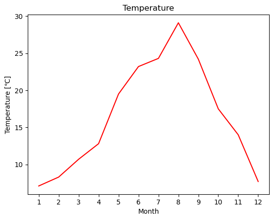

```julia
#折れ線グラフを描画する
ax = PyPlot.axes()

#軸と線の色を設定する
plot(month, temperature, color=:red)
title("Temperature")
xlabel("Month")
ylabel("Temperature [℃]")

#x軸のメモリを1ごとにする
Mx = matplotlib.ticker.MultipleLocator(1)
ax.xaxis.set_major_locator(Mx)
```

## 9-2. 棒グラフ

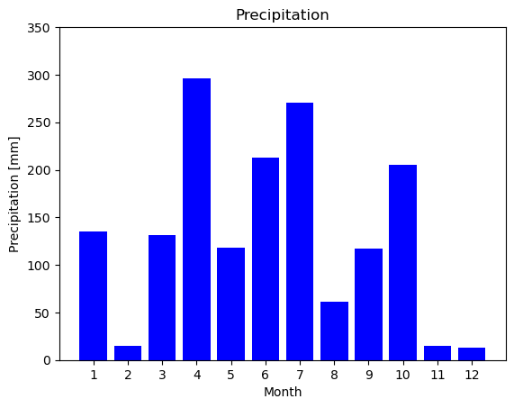

```
(0.0, 350.0)
```

```julia
#プロットを作成することを宣言
ax = PyPlot.axes()
#棒グラフを描画
b = bar(month, precipitation, color=:blue)
title("Precipitation")
xlabel("Month")
ylabel("Precipitation [mm]")

#x軸のメモリを1ごとにする
Mx = matplotlib.ticker.MultipleLocator(1)
ax.xaxis.set_major_locator(Mx)

#y軸の上限を設定する
ylim(0, 350)
```

## 9-3. 散布図

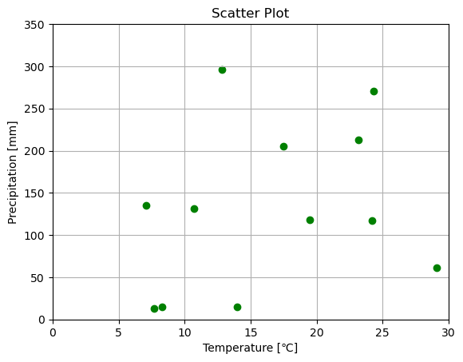

```
(0.0, 350.0)
```

```julia
#横軸に平均気温、縦軸に降水量をとった際の散布図を作成する
#プロットを作成することを宣言
ax = PyPlot.axes()
scatter(temperature, precipitation, color=:green)
title("Scatter Plot")
xlabel("Temperature [℃]")
ylabel("Precipitation [mm]")
grid("on")
xlim(0, 30)
ylim(0, 350)
```

## 9-4. ヒストグラム

ヒストグラムは**hist**を用いて、  
**hist(値, ビンの数, color=:ヒストグラムの色)**  
と記述することで描画できます。

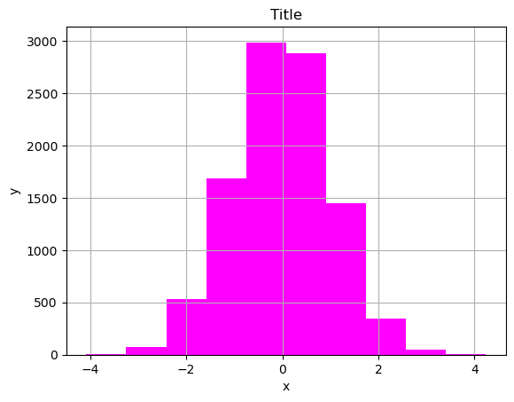

```julia
#正規分布に従う乱数を発生
x = randn(10000)

#binの数を指定
nbins = 10

#ヒストグラムをプロット
hist(x, nbins, color=:magenta)
title("Title")
xlabel("x")
ylabel("y")
grid("on")
```

## 9-5. 1枚の図に複数のグラフ

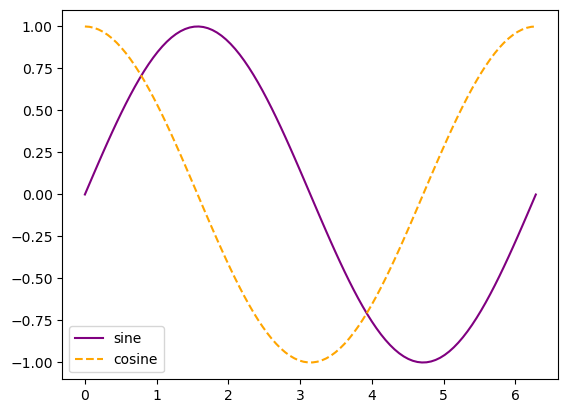

```
PyObject <matplotlib.legend.Legend object at 0x000000006FC2D9D0>
```

```julia
#sinカーブとcosカーブを1枚の図に描く
x = range(0,2pi, length = 100)
#y=sin(x)のグラフを実線で描画
plot(x, sin.(x), "-", label = "sine", color = :purple)
#y=cos(x)のグラフを破線で描画
plot(x, cos.(x), "--", label = "cosine", color = :orange)
legend()
```

## 9-6. 3Dプロット

3Dプロットを描画するには、**plot_surface**を用いて  
**plot_surface(x, y, z)**  
と記述することで描画します。  
今回は$z = x^2 + y^2$のプロットを書いてみます。

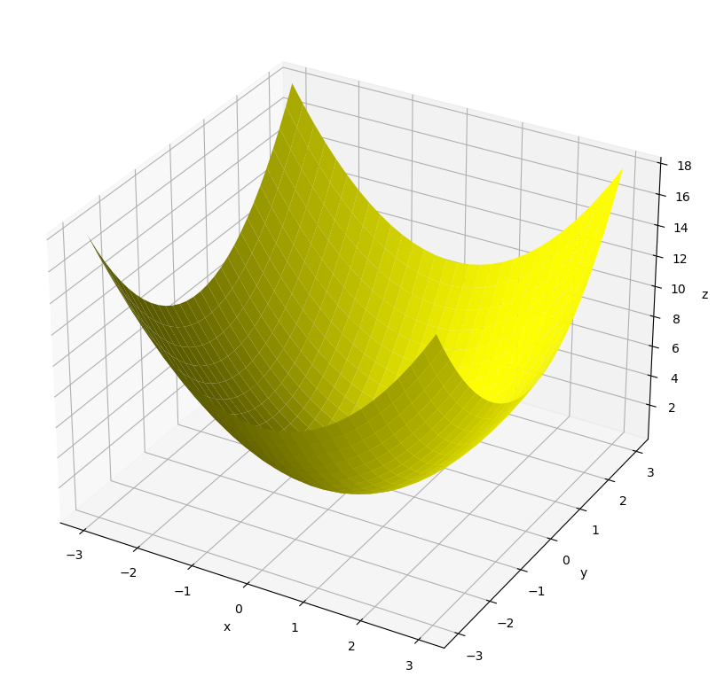

```
PyObject Text(0.09332506951644351, 0.012503188505254637, 'z')
```

```julia
n = 30
x = range(-3, 3, length = n)
y = range(-3, 3, length = n)

f(x, y) = x^2 + y^2
z = f.(x', y)

#表示するグラフのサイズを指定(しなくともよい)
fig = figure("pyplot_surfaceplot", figsize = (10, 10))

#グラフを描画
plot_surface(x, y, z, color = :yellow)
xlabel("x")
ylabel("y")
zlabel("z")
```

## 9-7. 複数プロットとファイルの保存

### 複数プロットの描画

プロットを複数描画する場合は、**subplot**を用いて、  
**subplot(行方向に何分割するか, 列方向に何分割するか, プロットに対応する番号)**  
と記述します。

### プロットの保存

プロットを保存する際には**savefig**を用いて、  
**savefig("パス名+ファイル名")**  
と記述します。

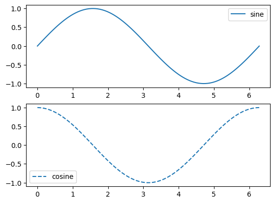

```julia
x = range(0, 2pi, length = 100)

#上側のプロットを作成
subplot(2, 1, 1)
plot(x, sin.(x), "-", label = "sine")
legend()

#下側のプロットを作成
subplot(2, 1, 2)
plot(x, cos.(x),"--", label = "cosine")
legend()

#描画した画像を保存
savefig(".\\Julia_Scientific_Programming_for_Beginners/image1.png")
```

# 10. データフレーム

## 10-1. データフレームの定義

### データフレームの作成

データフレームは二次元配置、つまり表形式でデータを持つためのフレームです。  
DataFrameは標準パッケージではないのでまずインストールしなければなりませんが、インストールが完了していればDataFrameを使用すると宣言し、  
**DataFrame(列名 = 列要素, 列名, 列要素, ……)**  
と記述することで作成できます。

```julia
#データフレームのインストール
using Pkg
Pkg.add("DataFrames")
```

```julia
using DataFrames
#A列とB列とそれぞれの中身を定義し、データフレームを作成
df = DataFrame(A = 1:5, B = ["Apple", "Banana", "Cherry", "Dorian", "Egg fruit"])
```

|  | A Int64 | B String |
| --- | --- | --- |
| 1 | 1 | Apple |
| 2 | 2 | Banana |
| 3 | 3 | Cherry |
| 4 | 4 | Dorian |
| 5 | 5 | Egg fruit |

各列の要素を見る場合には  
**データフレーム名.列名**  
で調べることができます。(Array型で返ってきます)

```julia
#A列の要素を見る
df.A
```

```
5-element Vector{Int64}:
 1
 2
 3
 4
 5
```

```julia
#列名はダブルクォーテーションで囲んでも同様に作動する
df."A"
```

```
5-element Vector{Int64}:
 1
 2
 3
 4
 5
```

### データフレームの初期化

**DataFrame()**でデータフレームを初期化し、0×0の表にすることができます。

```julia
#データフレームを初期化
df = DataFrame()
```

```julia
#初期化したデータフレームに列を挿入
df.A = 1:8
df.A
```

```
8-element Vector{Int64}:
 1
 2
 3
 4
 5
 6
 7
 8
```

```julia
df.B = ["A", "B", "C", "D", "E", "F", "G", "H"]
df
```

|  | A Int64 | B String |
| --- | --- | --- |
| 1 | 1 | A |
| 2 | 2 | B |
| 3 | 3 | C |
| 4 | 4 | D |
| 5 | 5 | E |
| 6 | 6 | F |
| 7 | 7 | G |
| 8 | 8 | H |

### データフレームの形の確認

データフレームの大きさを取得したい場合は、  
**size(データフレーム名)**  
と入力すれば、データフレームの**(行数, 列数)**が返ってきます  
また、最後に1を付ければ行数のみが、2を付ければ列数のみが返ってきます

```julia
size(df)
```

```
(8, 2)
```

```julia
#1列目の行数を確認
size(df, 1)
```

```
8
```

```julia
#1列目の列数を確認
size(df, 2)
```

```
2
```

## 10-2. データフレームの操作

### データ型の指定

データフレーム作成時には  
**列名 = 型[]**  
と記述することで各列の型を指定することができます。

```julia
df = DataFrame(A = Int[], B = String[])
```

|  | A | B |
| --- | --- | --- |
|  | Int64 | String |

### 行の追加

行を追加するためには**push**を用いて、  
**push!(データフレーム名, (1列目に追加する要素, 2列目に追加する要素, ……))**  
と記述します。

```julia
df = DataFrame(A = Int[], B = String[])
push!(df, (1, "Apple"))
push!(df, (2, "Banana"))
push!(df, (3, "Cherry"))
```

|  | A Int64 | B String |
| --- | --- | --- |
| 1 | 1 | Apple |
| 2 | 2 | Banana |
| 3 | 3 | Cherry |

### 行の削除

行を削除する場合は**delete**を用いて、  
**delete!(データフレーム名, 削除したい行数)**  
と記述します。

```julia
delete!(df, 3)
```

|  | A Int64 | B String |
| --- | --- | --- |
| 1 | 1 | Apple |
| 2 | 2 | Banana |

### 行の取得

最初の行を取得する場合は**first**を用い、  
**first(データフレーム名, 最初の何行を取得したいか)**  
と記述し、  
最後の行を取得する場合は**last**を用い、  
**last(データフレーム名, 最後の何行を取得したいか)**  
と記述します。  
また、スライスもpythonなどと同様に使用でき  
**データフレーム名[取得したい最初の行:取得したい最後の行, 取得したい最初の列:取得したい最後の列]**  
と記述することで、データフレームを切り出せます。

```julia
#新しいデータフレームを作成
df = DataFrame(A = 0:5:95, B = repeat(1:10, inner = 2), C = 1:20)
```

|  | A Int64 | B Int64 | C Int64 |
| --- | --- | --- | --- |
| 1 | 0 | 1 | 1 |
| 2 | 5 | 1 | 2 |
| 3 | 10 | 2 | 3 |
| 4 | 15 | 2 | 4 |
| 5 | 20 | 3 | 5 |
| 6 | 25 | 3 | 6 |
| 7 | 30 | 4 | 7 |
| 8 | 35 | 4 | 8 |
| 9 | 40 | 5 | 9 |
| 10 | 45 | 5 | 10 |
| 11 | 50 | 6 | 11 |
| 12 | 55 | 6 | 12 |
| 13 | 60 | 7 | 13 |
| 14 | 65 | 7 | 14 |
| 15 | 70 | 8 | 15 |
| 16 | 75 | 8 | 16 |
| 17 | 80 | 9 | 17 |
| 18 | 85 | 9 | 18 |
| 19 | 90 | 10 | 19 |
| 20 | 95 | 10 | 20 |

```julia
#最初の行を取得する
first(df, 3)
```

|  | A Int64 | B Int64 | C Int64 |
| --- | --- | --- | --- |
| 1 | 0 | 1 | 1 |
| 2 | 5 | 1 | 2 |
| 3 | 10 | 2 | 3 |

```julia
#最後の行を取得する
last(df, 3)
```

|  | A Int64 | B Int64 | C Int64 |
| --- | --- | --- | --- |
| 1 | 85 | 9 | 18 |
| 2 | 90 | 10 | 19 |
| 3 | 95 | 10 | 20 |

```julia
#1行目から10行目を取得する
df[1:10,:]
```

|  | A Int64 | B Int64 | C Int64 |
| --- | --- | --- | --- |
| 1 | 0 | 1 | 1 |
| 2 | 5 | 1 | 2 |
| 3 | 10 | 2 | 3 |
| 4 | 15 | 2 | 4 |
| 5 | 20 | 3 | 5 |
| 6 | 25 | 3 | 6 |
| 7 | 30 | 4 | 7 |
| 8 | 35 | 4 | 8 |
| 9 | 40 | 5 | 9 |
| 10 | 45 | 5 | 10 |

```julia
#Aが50より大きいものだけ取得する
df[df.A .> 50, :]
```

|  | A Int64 | B Int64 | C Int64 |
| --- | --- | --- | --- |
| 1 | 55 | 6 | 12 |
| 2 | 60 | 7 | 13 |
| 3 | 65 | 7 | 14 |
| 4 | 70 | 8 | 15 |
| 5 | 75 | 8 | 16 |
| 6 | 80 | 9 | 17 |
| 7 | 85 | 9 | 18 |
| 8 | 90 | 10 | 19 |
| 9 | 95 | 10 | 20 |

### サマリの確認

データフレームのサマリを確認するには**describe**を用いて、  
**describe(データフレーム名)** と記述すると取得できます。

```julia
describe(df)
```

|  | variable Symbol | mean Float64 | min Int64 | median Float64 | max Int64 | nmissing Int64 | eltype DataType |
| --- | --- | --- | --- | --- | --- | --- | --- |
| 1 | A | 47.5 | 0 | 47.5 | 95 | 0 | Int64 |
| 2 | B | 5.5 | 1 | 5.5 | 10 | 0 | Int64 |
| 3 | C | 10.5 | 1 | 10.5 | 20 | 0 | Int64 |

### 列の削除

列を削除する場合は、**select**を用いて、  
**select(データフレーム名, Not(:カラム名))**  
もしくは、  
**select!(データフレーム名, Not(:カラム名))**  
と記述します。  
後者の記述方法は元のデータフレームからも列を削除してしまうことになります。

```julia
#列Bを削除
select(df, Not(:B))
```

|  | A Int64 | C Int64 |
| --- | --- | --- |
| 1 | 0 | 1 |
| 2 | 5 | 2 |
| 3 | 10 | 3 |
| 4 | 15 | 4 |
| 5 | 20 | 5 |
| 6 | 25 | 6 |
| 7 | 30 | 7 |
| 8 | 35 | 8 |
| 9 | 40 | 9 |
| 10 | 45 | 10 |
| 11 | 50 | 11 |
| 12 | 55 | 12 |
| 13 | 60 | 13 |
| 14 | 65 | 14 |
| 15 | 70 | 15 |
| 16 | 75 | 16 |
| 17 | 80 | 17 |
| 18 | 85 | 18 |
| 19 | 90 | 19 |
| 20 | 95 | 20 |

### 列名の変更

列の削除と同様**select**を用いて、  
**select(データフレーム名, :変更したいカラム名 => :変更後のカラム名)**  
もしくは、  
**select!(データフレーム名, :変更したいカラム名 => :変更後のカラム名)**  
と記述します。  
後者の記述方法は元のデータフレームの列名も変更することになります。

```julia
#A列をAA、C列をCCに改名する
select(df, :A => :AA, :C => :CC)
```

|  | AA Int64 | CC Int64 |
| --- | --- | --- |
| 1 | 0 | 1 |
| 2 | 5 | 2 |
| 3 | 10 | 3 |
| 4 | 15 | 4 |
| 5 | 20 | 5 |
| 6 | 25 | 6 |
| 7 | 30 | 7 |
| 8 | 35 | 8 |
| 9 | 40 | 9 |
| 10 | 45 | 10 |
| 11 | 50 | 11 |
| 12 | 55 | 12 |
| 13 | 60 | 13 |
| 14 | 65 | 14 |
| 15 | 70 | 15 |
| 16 | 75 | 16 |
| 17 | 80 | 17 |
| 18 | 85 | 18 |
| 19 | 90 | 19 |
| 20 | 95 | 20 |

```julia
#先のコードではselectに!を付けていないため、元のdfに変更はない
df
```

|  | A Int64 | B Int64 | C Int64 |
| --- | --- | --- | --- |
| 1 | 0 | 1 | 1 |
| 2 | 5 | 1 | 2 |
| 3 | 10 | 2 | 3 |
| 4 | 15 | 2 | 4 |
| 5 | 20 | 3 | 5 |
| 6 | 25 | 3 | 6 |
| 7 | 30 | 4 | 7 |
| 8 | 35 | 4 | 8 |
| 9 | 40 | 5 | 9 |
| 10 | 45 | 5 | 10 |
| 11 | 50 | 6 | 11 |
| 12 | 55 | 6 | 12 |
| 13 | 60 | 7 | 13 |
| 14 | 65 | 7 | 14 |
| 15 | 70 | 8 | 15 |
| 16 | 75 | 8 | 16 |
| 17 | 80 | 9 | 17 |
| 18 | 85 | 9 | 18 |
| 19 | 90 | 10 | 19 |
| 20 | 95 | 10 | 20 |